# Models Update

Jina Park, Phuc Nguyen

12/5/2017

### Research Question 1

- Predicting hotspots of specific crimes and how they changed over time and space.
- Are certain types of crimes more prevalent in certain areas than others?
- How have these hotspots changed over time? If they have changed over time, how has it changed relative to changes in income, demographics, age, etc?

### Research Question 2

- Examining police traffic stops and subsequent arrests to determine whether certain ethnic minorities are stopped/arrested more than others.
- Are certain ethnic groups more likely to be arrested/stopped in certain areas than others? For instance, are blacks/hispanics more likely to be stopped/arrested in predominantly white neighborhoods?
- We would like to examine the relationship between traffic stops/arrests and the actual crime rates of different ethnic groups. For instance, are blacks/hispanics getting stopped/arrested at a disproportionately greater rate than they are committing crimes?

#### Load Libraries

```r
library(tidyr)
library(rjags)
library(ggplot2)
library(dplyr)
library(tidyverse)
library(MacBayes)
library(choroplethrZip)
library(rgdal)
```

#### Map cleanup

```r
cleanup <- theme(panel.grid.major = element_blank(), panel.grid.minor = element_blank(),
        panel.background = element_rect(fill = 'white', colour = 'white'),
        axis.line = element_line(colour = "white"),
        axis.ticks=element_blank(), axis.text.x=element_blank(),
        axis.text.y=element_blank())
```

#### Clean data

```r
#Load data
Crime = read.csv('Crime_sample_2010_to_2017.csv')

Crime = Crime %>%
  mutate(Date = as.POSIXct(strptime(Date, "%Y-%m-%d %H:%M:%S"))) %>%
  filter(!is.na(Latitude))
```

#### Project observations to ZIP codes boundaries

```r
#load shapefile
zip_shp <- readOGR(dsn="Boundaries - ZIP Codes", layer="geo_export_e1262361-5c82-45ee-8427-ef228e06dc4a")
temp <- zip_shp
zip_df <- fortify(temp, region = "zip")

#needs to reassign CRS for shapefile
new_CRS <- CRS("+init=epsg:4326 +proj=longlat +datum=WGS84 +no_defs +ellps=WGS84 +towgs84=0,0,0")
zip_shp <- sp::spTransform(zip_shp, new_CRS)

#summarize crime count per year
years <- unique(Crime$Year)
Hotspot_Crime <- data.frame()

for(i in 1:length(years)){
  year <- years[i]
  Current_Year <- Crime %>% filter(Year == year)

  locations <- with(Current_Year, as.data.frame(cbind(Longitude, Latitude)))
  coordinates(locations) <- ~Longitude+Latitude
  proj4string(locations) <- CRS("+init=epsg:4326")

  #prepping the data: project points to polygons
  proj4string(zip_shp) <- new_CRS
  proj4string(locations) <- new_CRS
  by_zip <- over(locations, zip_shp)

  by_zip <- by_zip %>%
    group_by(zip) %>%
    dplyr::summarise(total=n()) %>%
    filter(!is.na(zip)) %>%
    mutate(id = as.character(zip))

  total_map <- left_join(zip_df, by_zip)
  total_map <- total_map %>% mutate(Year = year)

  Hotspot_Crime <- rbind(Hotspot_Crime, total_map)
}
```

#### Add demographic information to Model Data

```r
data("df_zip_demographics")
Demographics <- df_zip_demographics %>% mutate(zip = region)
Hotspot_Crime <- inner_join(Hotspot_Crime, Demographics, by="zip")
Model_Data <- Hotspot_Crime %>%
  select(-c(lat, long, order, piece, group, hole)) %>% distinct
```

#### Matrix data: crime counts, populations by zipcode and year

#### Nested data: crime counts, population, standardized year

```r
Model_Data <- transform(Model_Data, id=match(zip, unique(zip)))
Model_Data$time = Model_Data$Year-2009
Model_Data$racegr <- ifelse(Model_Data$percent_white >80, 1,
                            ifelse(Model_Data$percent_white <=80 & Model_Data$percent_white > 60,2,
                            ifelse(Model_Data$percent_white <=60 & Model_Data$percent_white > 40,3,
                            ifelse(Model_Data$percent_white <=40 & Model_Data$percent_white > 20,4, 5))))
Model_Data$income = scale(Model_Data$per_capita_income)[,1]

write.csv(Model_Data, "Crime_models_data.csv")
```

### Load Data:

```r
Model_Data = read.csv("Crime_models_data.csv")
```

# Research Question 1

**Plot of $log(y_{ij}/n_{i})$ vs year**

```r
Crime_count_log <- Model_Data %>%
  mutate(log_rate = log(total/total_population)) %>%
  select(zip, Year, log_rate)
head(Crime_count_log)
```

```
##     zip Year  log_rate
## 1 60601 2010 -7.103733
## 2 60602 2010 -5.901950
## 3 60603 2010 -6.782192
## 4 60604 2010 -6.028279
## 5 60605 2010 -7.822925
## 6 60606 2010 -7.240291
```

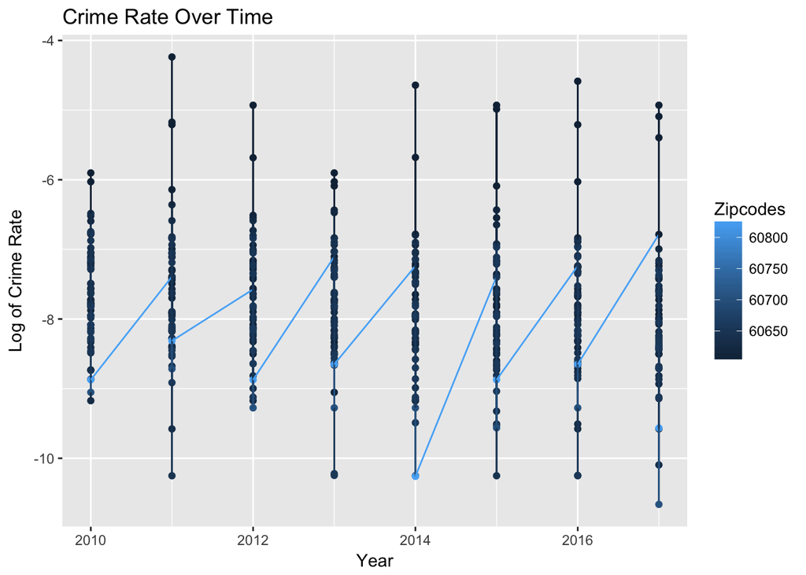

```r
ggplot(Crime_count_log, aes(x=Year, y=log_rate, colour=zip)) + geom_point() + geom_line()  + labs(title="Crime Rate Over Time", y="Log of Crime Rate", x="Year", color="Zipcodes")
```

**Plot of $log(y_{ij}/n_{i})$ vs per capita income**

```r
Model_Data_1 <- Model_Data %>%
  filter(Year == 2010) %>%
  mutate(percent_nonwhite = 100 - percent_white) %>%
  select(zip, per_capita_income, percent_nonwhite) %>%
  right_join(Crime_count_log, by="zip")
head(Model_Data_1)
```

```
##     zip per_capita_income percent_nonwhite Year  log_rate
## 1 60601             89136               37 2010 -7.103733
## 2 60602             66748               38 2010 -5.901950
## 3 60603             73239               39 2010 -6.782192
## 4 60604            135807               20 2010 -6.028279
## 5 60605             58338               42 2010 -7.822925
## 6 60606             83005               25 2010 -7.240291
```

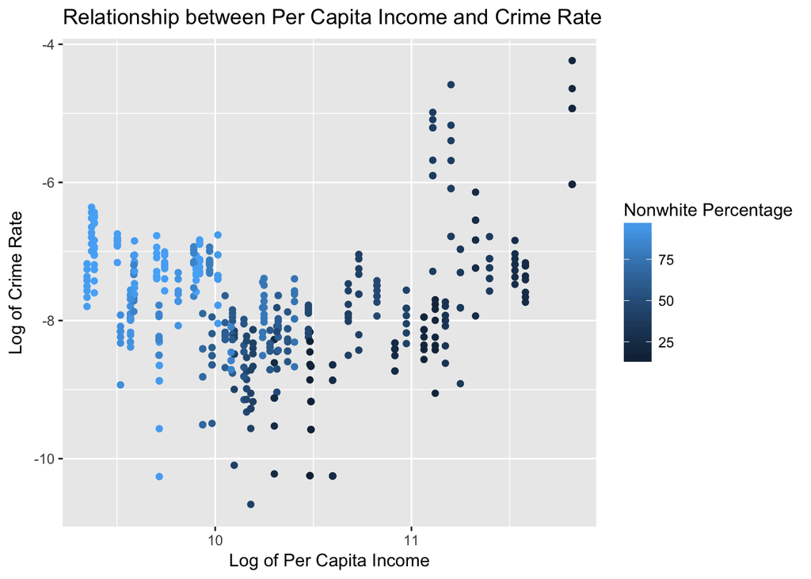

```r
ggplot(Model_Data_1, aes(x=log(per_capita_income), y=log_rate, colour=percent_nonwhite)) + geom_point() + labs(x="Log of Per Capita Income", y="Log of Crime Rate", title="Relationship between Per Capita Income and Crime Rate", color="Nonwhite Percentage")
```

**Plot of $log(y_{ij}/n_{i})$ vs nonwhite percentage**

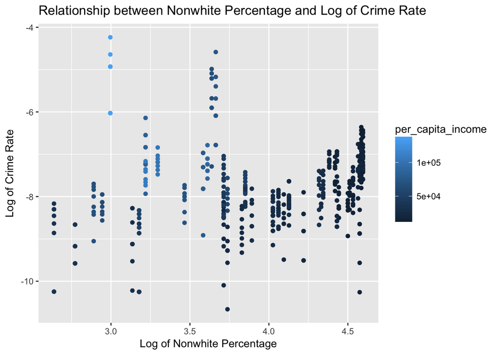

```r
ggplot(Model_Data_1, aes(x=log(percent_nonwhite), y=log_rate, colour=per_capita_income)) + geom_point() + labs(x="Log of Nonwhite Percentage", y="Log of Crime Rate", title="Relationship between Nonwhite Percentage and Log of Crime Rate")
```

## Model 0

#### Data

$$y_{ij} \sim Bin(p_{ij}, n_{i})$$
$$logit(p_{ij}) = \beta * time_{j}$$

#### Priors

$$\beta \sim N(0, 1000^2)$$

- i: zipcodes in Chicago (58 total in our data)
- j: years (from 2010 to 2017)
- y[i, j]: observed count of violent crimes in Chicago by year and zipcode
- p[i, j]: probability of being a victim in location i and time j
- n[i]: the population in zipcode i
- $\beta$: time trend
- time[j]: the time in years

```r
#Specify the model
crime_model_0 <- "model{
    #Data
    for(j in 1:ns){
      y[j] ~ dbin(p[j], n[j])
      logit(p[j]) = alpha + beta*time[j]
    }

    #Priors
    beta ~ dnorm(0, 1/1000^2)
    alpha ~ dnorm(0, 1/1000^2)

}"

#set up an algorithm to simulate the posterior by
#combining the model (nba_model) and data (y)
#set the random number seed
crime_jags_0 <- jags.model(textConnection(crime_model_0), data=list(y=Model_Data$total, n=Model_Data$total_population, time=Model_Data$time, ns=nrow(Model_Data)),inits=list(.RNG.name="base::Wichmann-Hill", .RNG.seed=1989))
#simulate a sample from the posterior
crime_sim_0 <- coda.samples(crime_jags_0, variable.names=c("beta", "alpha"), n.iter=20000)


#store the samples in a data frame:
crime_data_0 <- data.frame(crime_sim_0[[1]])
```

### Check for convergence

```r
#check for convergece
#from: https://rpubs.com/corey_sparks/32494
init.rng1<-list(".RNG.seed" = 1234, ".RNG.name" = "base::Mersenne-Twister")
init.rng2<-list(".RNG.seed" = 5678, ".RNG.name" = "base::Mersenne-Twister")
mod<-jags.model(file=textConnection(crime_model_0),list(y=Model_Data$total, n=Model_Data$total_population, time=Model_Data$time, ns=nrow(Model_Data)),inits =list(init.rng1, init.rng2) , n.chains=2)
update(mod, 10000)
samps<-coda.samples(mod, variable.names=c("beta","alpha"), n.iter=5000, n.thin=5)
gelman.diag(samps)
```

```
## Potential scale reduction factors:
##
##       Point est. Upper C.I.
## alpha          1          1
## beta           1          1
##
## Multivariate psrf
##
## 1
```

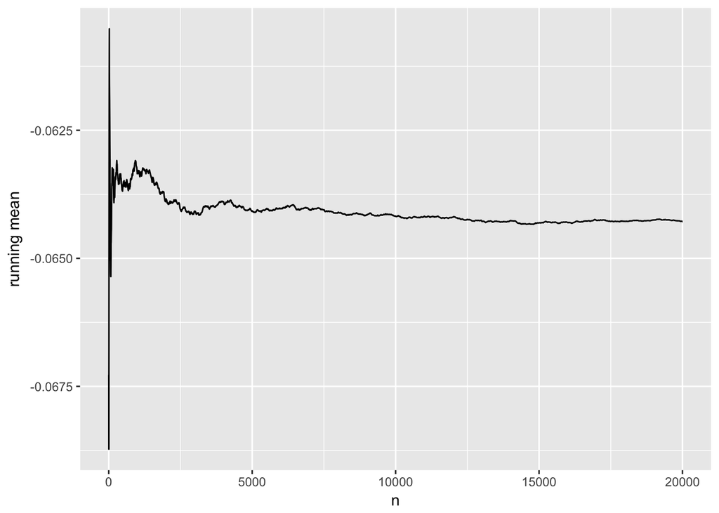

```r
#running mean plot
running_mean_plot(crime_data_0$beta)
```

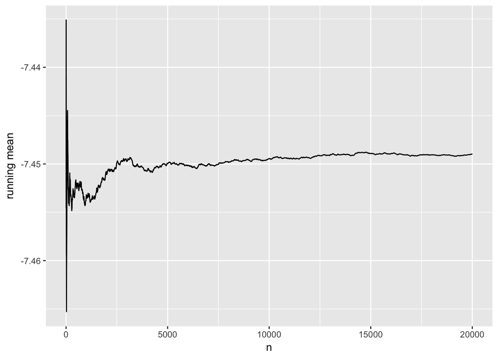

```r
running_mean_plot(crime_data_0$alpha)
```

### Parameter Inferences

#### Posterior Distribution Plots

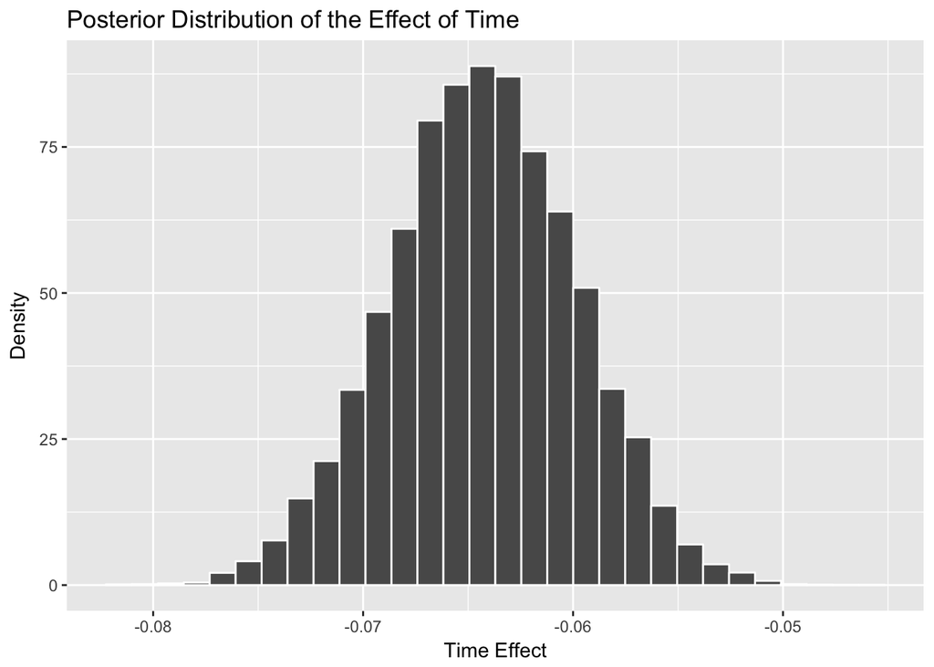

```r
ggplot(crime_data_0, aes(x=beta)) + geom_histogram(aes(y=..density..), colour="white") + labs(title="Posterior Distribution of the Effect of Time", x="Time Effect", y="Density")
```

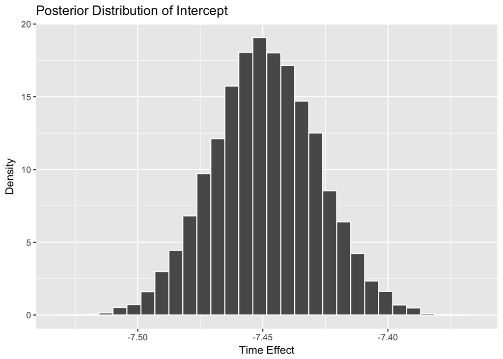

```r
ggplot(crime_data_0, aes(x=alpha)) + geom_histogram(aes(y=..density..), colour="white") + labs(title="Posterior Distribution of Intercept", x="Time Effect", y="Density")
```

#### Confidence Intervals and Posterior Means of Crime Model 0 Parameters

```r
crime_model_0_CI <- matrix(nrow=2, ncol=2)

for (i in 1:2) {
      crime_model_0_CI[i,] <- quantile(crime_data_0[[i]], c(0.025, 0.975))
}

crime_model_0_mean <- matrix(nrow=2, ncol=1)
for (i in 1:2) {
      crime_model_0_mean[i, ] <- mean(crime_data_0[[i]])
}

crime_model_0_table <- cbind(crime_model_0_CI, crime_model_0_mean)
rownames(crime_model_0_table) <- names(crime_data_0)
colnames(crime_model_0_table) <- c("2.5%", "97.5%", "Mean")
# as.table(crime_model_0_table)
```

## Model 1

### Notation

- i: zipcodes in Chicago (58 total in our data)
- j: years (from 2010 to 2017)
- y[i, j]: observed count of violent crimes in Chicago by year and zipcode
- p[i, j]: probability of being a victim in location i and time j
- n[i, j]: the population in zipcode i in time j.
- time[j]: the time in years
- $\delta$[i]: the spatial temporal interaction term

### Specify the Model

We are modeling the count of crime incidents by year and zipcodes using a binomial distribution, in which the parameters are the probability of being a victim and the total population in location i and year j.

We modeled the probability of being a victim using a logit function of the grand crime rate of Chicago and the inclusion of several random effects. It is also a function of time and its interaction with location.

#### Data

$$y_{ij} \sim Bin(p_{ij}, n_{i})$$
$$logit(p_{ij}) = \beta_{i} + \delta_{i} * time_{j}$$

#### Priors

$$\beta_{i} \sim N(0, \tau_{0})$$
$$\delta_{i} \sim N(0, \tau_{1})$$

#### Hyperpriors

$$\tau_0 \sim Gamma(0.5, 0.0005)$$

$$\tau_1 \sim Gamma(0.5, 0.0005)$$

```r
#Data
data = list(y=Model_Data$total, n=Model_Data$total_population, time=Model_Data$time, zipid=Model_Data$id, ns=length(Model_Data$total), nzip=length(unique(Model_Data$id)))
```

```r
#Specify the model
crime_model_1 <- "model{
    #Data
    for(i in 1:ns) {
      y[i] ~ dbin(p[i], n[i])
      logit(p[i]) = beta[zipid[i]] + delta[zipid[i]]*time[i]
    }

    #Priors
    for(j in 1:nzip){
      delta[j] ~ dnorm(0, tau_1)
      beta[j] ~ dnorm(0, tau_0)
    }

    #Hyperpriors
    tau_0 ~ dgamma(0.5, 0.0005)
    tau_1 ~ dgamma(0.5, 0.0005)

}"

#set up an algorithm to simulate the posterior
#set the random number seed
init.rng1<-list(".RNG.seed" = 1998, ".RNG.name" = "base::Mersenne-Twister")
crime_jags_1 <- jags.model(textConnection(crime_model_1), data=data,
                    inits=init.rng1)
#simulate a sample from the posterior
crime_sim_1 <- coda.samples(crime_jags_1, variable.names=c("delta", "beta", "tau_0", "tau_1"), n.iter=30000)


#store the samples in a data frame:
crime_data_1 <- data.frame( crime_sim_1[[1]])
```

### Check for convergence

```r
#check for convergece
#from: https://rpubs.com/corey_sparks/32494
init.rng1<-list(".RNG.seed" = 1234, ".RNG.name" = "base::Mersenne-Twister")
init.rng2<-list(".RNG.seed" = 5678, ".RNG.name" = "base::Mersenne-Twister")
mod<-jags.model(file=textConnection(crime_model_1), data=data,inits =list(init.rng1, init.rng2) , n.chains=2)
update(mod, 10000)
samps<-coda.samples(mod, variable.names=c("delta", "alpha", "tau_delta", "tau_alpha"), n.iter=5000, n.thin=5)
gelman.diag(samps)
```

```
## Potential scale reduction factors:
##
##           Point est. Upper C.I.
## delta[1]        1.00       1.00
## delta[2]        1.00       1.00
## delta[3]        1.00       1.00
## delta[4]        1.00       1.01
## delta[5]        1.00       1.00
## delta[6]        1.00       1.00
## delta[7]        1.00       1.01
## delta[8]        1.00       1.01
## delta[9]        1.00       1.00
## delta[10]       1.00       1.00
## delta[11]       1.00       1.01
## delta[12]       1.00       1.00
## delta[13]       1.00       1.00
## delta[14]       1.01       1.03
## delta[15]       1.00       1.00
## delta[16]       1.00       1.01
## delta[17]       1.01       1.03
## delta[18]       1.00       1.00
## delta[19]       1.00       1.00
## delta[20]       1.00       1.00
## delta[21]       1.00       1.01
## delta[22]       1.00       1.00
## delta[23]       1.00       1.00
## delta[24]       1.00       1.00
## delta[25]       1.00       1.01
## delta[26]       1.00       1.00
## delta[27]       1.00       1.02
## delta[28]       1.00       1.00
## delta[29]       1.00       1.00
## delta[30]       1.00       1.00
## delta[31]       1.00       1.01
## delta[32]       1.00       1.00
## delta[33]       1.00       1.01
## delta[34]       1.00       1.00
## delta[35]       1.00       1.00
## delta[36]       1.00       1.01
## delta[37]       1.00       1.00
```

[output cut: 10 more lines]

```
## delta[48]       1.00       1.00
## delta[49]       1.01       1.04
## delta[50]       1.00       1.01
## delta[51]       1.00       1.01
## delta[52]       1.00       1.00
## delta[53]       1.00       1.00
## delta[54]       1.01       1.03
## delta[55]       1.00       1.01
## delta[56]       1.00       1.00
## delta[57]       1.00       1.01
## delta[58]       1.01       1.03
##
## Multivariate psrf
##
## 1.06
```

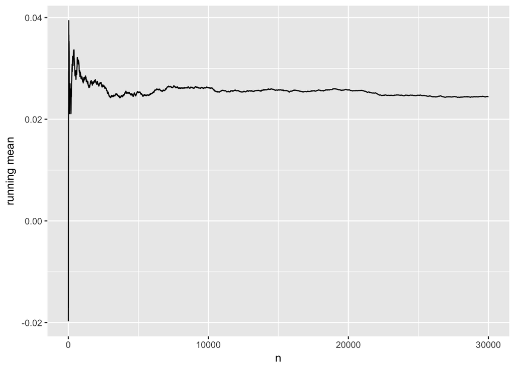

```r
running_mean_plot(crime_data_1$delta.1.)
```

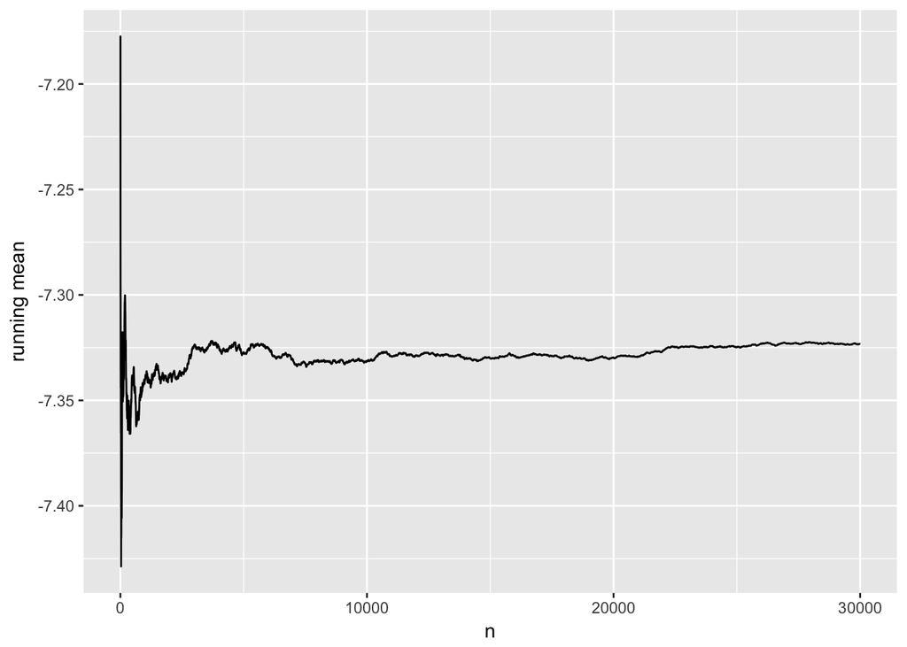

```r
running_mean_plot(crime_data_1$beta.1.)
```

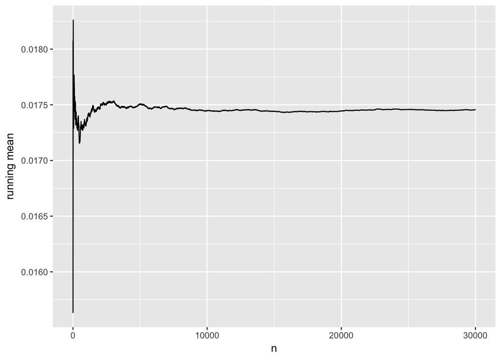

```r
running_mean_plot(crime_data_1$tau_0)
```

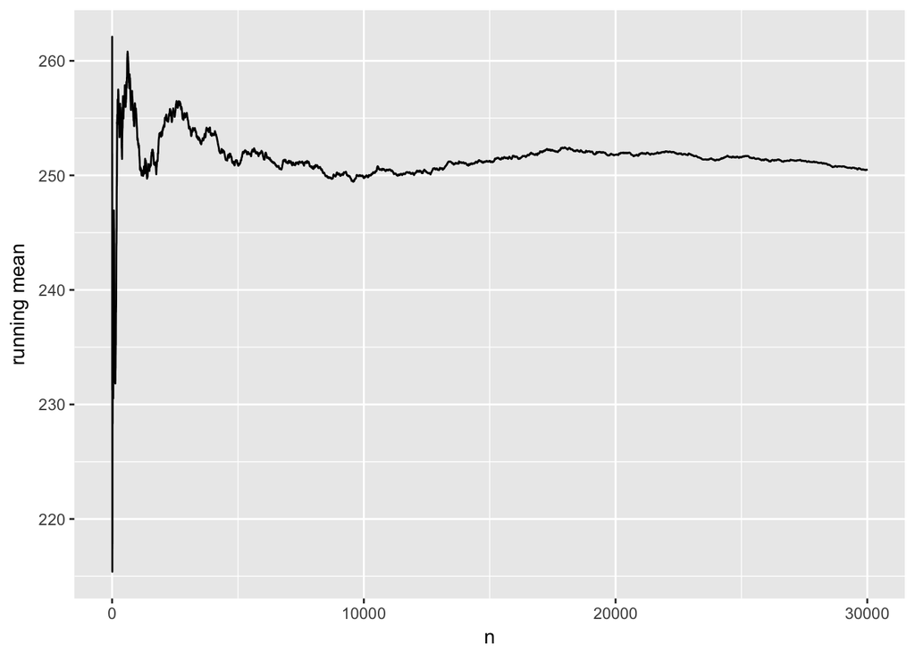

```r
running_mean_plot(crime_data_1$tau_1)
```

### Parameter Interpretation

#### Posterior Distribution

[figure not shown]

```r
ggplot(crime_data_1, aes(x=delta.1.)) + geom_histogram(aes(y=..density..), colour="white") + labs(title="Posterior Distribution of the Crime Differential Growth in 2010", x="Crime Differential Growth", y="Density")
```

### Confidence Intervals and Posterior Means of Crime Model 1 Parameters

```r
n = length(unique(Model_Data$zip))

#posterior mean and quantile of delta only

crime_model_1_CI <- matrix(nrow=n, ncol=2)
for (i in 1:n) {
      crime_model_1_CI[i, ] <- quantile(crime_data_1[[i+n]], c(0.025, 0.975))
}

crime_model_1_mean <- matrix(nrow=n, ncol=1)
for (i in 1:n) {
      crime_model_1_mean[i, ] <- mean(crime_data_1[[i+n]])
}

crime_model_1_table <- cbind(crime_model_1_CI, crime_model_1_mean)
rownames(crime_model_1_table) <- names(crime_data_1)[59:116]
colnames(crime_model_1_table) <- c("2.5%", "97.5%", "Mean")
# as.table(crime_model_1_table)
```

## Crime Model 1 Visualizations

### Map of Crime Differential Growth by Zipcode (Using Model 1)

```r
zip <- readOGR(dsn="Boundaries - ZIP Codes", layer="geo_export_e1262361-5c82-45ee-8427-ef228e06dc4a")
zip_df <- fortify(zip, region = "zip")
crime_model_1_delta <- left_join(zip_df, data.frame(id=as.character(unique(Model_Data$zip)), delta=crime_model_1_mean), by='id')
head(crime_model_1_delta)
```

```
##        long      lat order  hole piece    id   group      delta
## 1 -87.62271 41.88884     1 FALSE     1 60601 60601.1 0.02445683
## 2 -87.62232 41.88879     2 FALSE     1 60601 60601.1 0.02445683
## 3 -87.62120 41.88866     3 FALSE     1 60601 60601.1 0.02445683
## 4 -87.62064 41.88860     4 FALSE     1 60601 60601.1 0.02445683
## 5 -87.62058 41.88859     5 FALSE     1 60601 60601.1 0.02445683
## 6 -87.62055 41.88859     6 FALSE     1 60601 60601.1 0.02445683
```

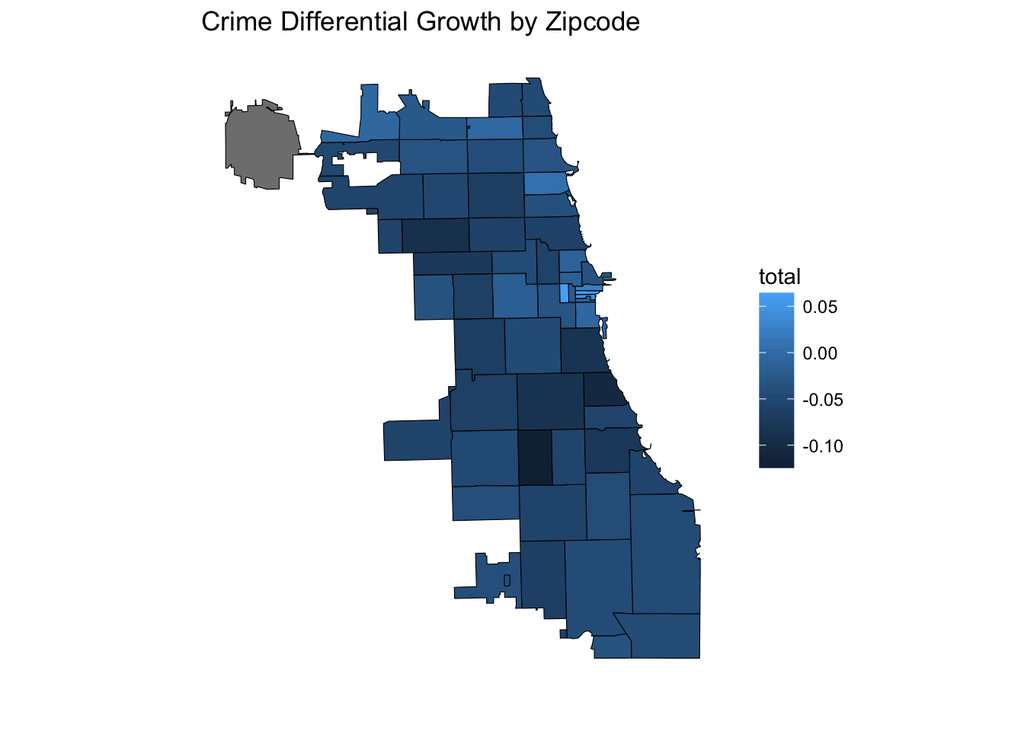

```r
model_1_map <- ggplot()
model_1_map <- model_1_map +  geom_polygon(data = crime_model_1_delta, aes(x=long, y=lat, group=group, fill=delta), color = "black", size=0.2)
model_1_map <- model_1_map + coord_map()
model_1_map <- model_1_map + labs(x="", y="", title=paste("Crime Differential Growth by Zipcode"), fill="total")
model_1_map <- model_1_map + cleanup
print(model_1_map)
```

### Variability of the Crime Differential Growth

```r
sqrt(1/mean(crime_data_1$tau_1))
```

```
## [1] 0.06318261
```

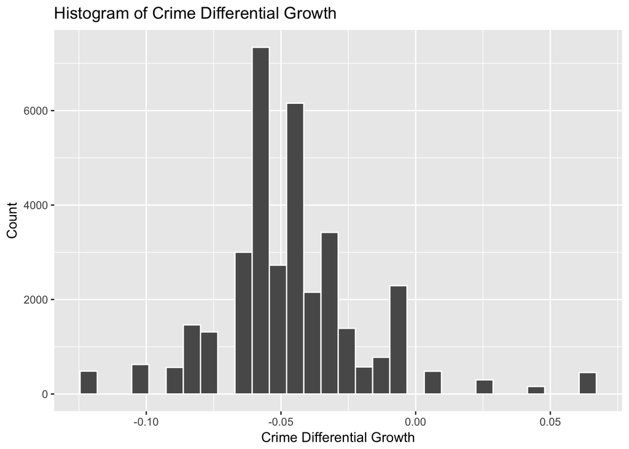

```r
ggplot(crime_model_1_delta, aes(x=delta)) + geom_histogram(colour="white") + labs(x="Crime Differential Growth", y="Count", title="Histogram of Crime Differential Growth")
```

# Model 3 – Use demographics information

### Notation

- i: zipcodes in Chicago (58 total in our data)
- j: years (from 2010 to 2017)
- y[i, j]: observed count of violent crimes in Chicago by year and zipcode
- p[i, j]: probability of being a victim in location i and time j
- n[i, j]: the population in zipcode i in time j.
- time[j]: the time in years
- $\delta$[i]: the spatial temporal interaction term
- $\sigma$[i]: the income trend
- income[i]: income for each zipcode in Chicago

### Specify the Model

#### Data

$$y_{ij} \sim Bin(p_{ij}, n_{i})$$
$$logit(p_{ij}) = \beta_{i} + \sigma_{j} * income_{i}$$

#### Priors

$$\beta_{i} \sim N(0, \tau_{0})$$
$$\sigma_{j} \sim N(0, \tau_{1})$$

#### Hyperprior

$$\tau_{0} \sim Gamma(0.5, 0.0005)$$
$$\tau_{1} \sim Gamma(0.5, 0.0005)$$

```r
Model3_Data <- Model_Data %>% filter(Year==2010)
data = list(y=Model3_Data$total, n=Model3_Data$total_population, zipid=Model3_Data$id, racegr=Model3_Data$racegr, income=Model3_Data$income, ns=nrow(Model3_Data), nzip=length(unique(Model3_Data$zip)))
```

```r
#Specify the model
crime_model_3 <- "model{
    #Data
    for(i in 1:ns) {
      y[i] ~ dbin(p[i], n[i])
      logit(p[i]) = beta[racegr[i]] + sigma[racegr[i]]*income[i]
    }

    #Priors
    for(j in 1:5){
      sigma[j] ~ dnorm(0, tau_1)
      beta[j] ~ dnorm(0, tau_0)
    }

    #Hyperpriors
    tau_0 ~ dgamma(0.5, 0.0005)
    tau_1 ~ dgamma(0.5, 0.0005)

}"

#set up an algorithm to simulate the posterior by
#combining the model (nba_model) and data (y)
#set the random number seed
crime_jags_3 <- jags.model(textConnection(crime_model_3), data=data,
                    inits=list(.RNG.name="base::Wichmann-Hill", .RNG.seed=1989))
#simulate a sample from the posterior
#note that we specify both mu and tau variables
crime_sim_3 <- coda.samples(crime_jags_3, variable.names=c("sigma", "tau_0", "beta","tau_1"), n.iter=30000, n.thin=5)


#store the samples in a data frame:
crime_data_3 <- data.frame(crime_sim_3[[1]])
```

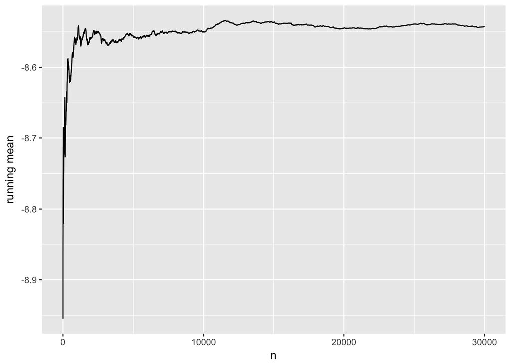

```r
running_mean_plot(crime_data_3$beta.1.)
```

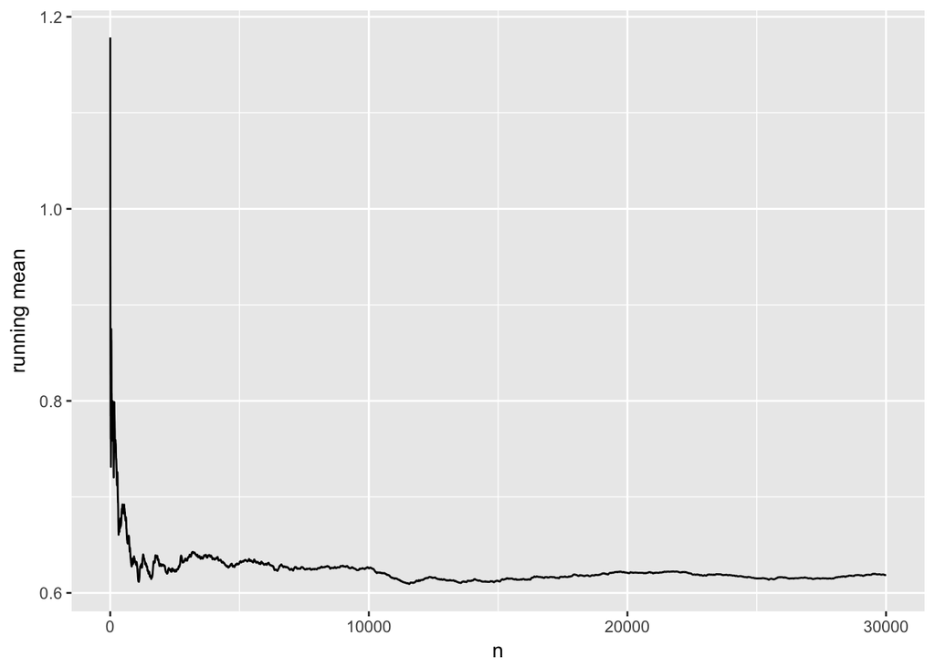

```r
running_mean_plot(crime_data_3$sigma.1.)
```

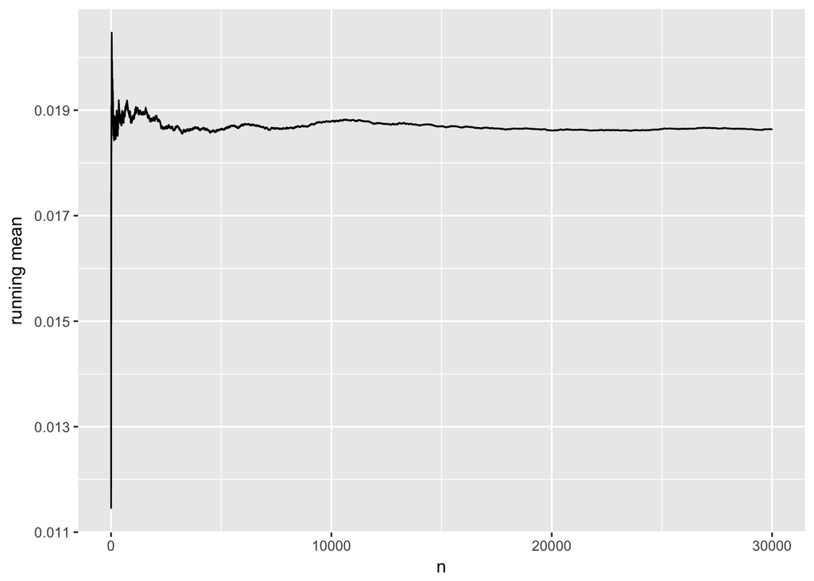

```r
running_mean_plot(crime_data_3$tau_0)
```

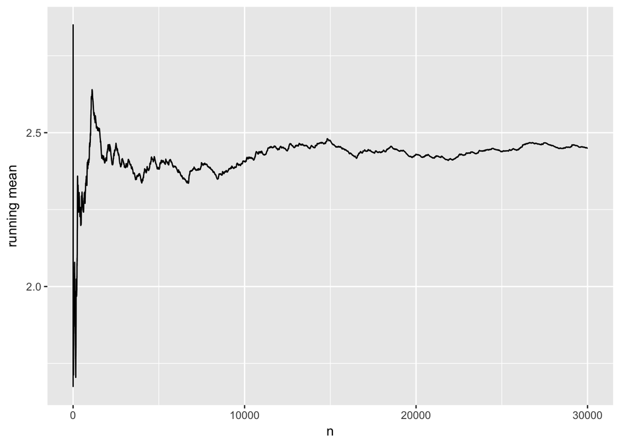

```r
running_mean_plot(crime_data_3$tau_1)
```

## Crime Model 3 Visualizations

```r
posterior_means <- crime_data_3 %>% colMeans()
posterior_means
```

```
##     beta.1.     beta.2.     beta.3.     beta.4.     beta.5.    sigma.1.
## -8.54288605 -8.53084433 -7.89663773 -7.45596846 -7.67992852  0.61881602
##    sigma.2.    sigma.3.    sigma.4.    sigma.5.       tau_0       tau_1
##  0.54568448  0.74068777  1.00026574 -0.59811708  0.01863882  2.44962106
```

```r
crime_model_3_sigma <- Model_Data
crime_model_3_sigma$beta <- recode(crime_model_3_sigma$racegr, `1`=posterior_means[1],
                                   `2`=posterior_means[2],
                                   `3`=posterior_means[3],
                                   `4`=posterior_means[4],
                                   `5`=posterior_means[5])
crime_model_3_sigma$sigma <- recode(crime_model_3_sigma$racegr, `1`=posterior_means[6],
                                   `2`=posterior_means[7],
                                   `3`=posterior_means[8],
                                   `4`=posterior_means[9],
                                   `5`=posterior_means[10])
crime_model_3_sigma <- crime_model_3_sigma %>%
  mutate(id = as.character(zip)) %>%
  right_join(zip_df, by="id")
```

### Income Differential Growth by Zipcode (Using Model 3)

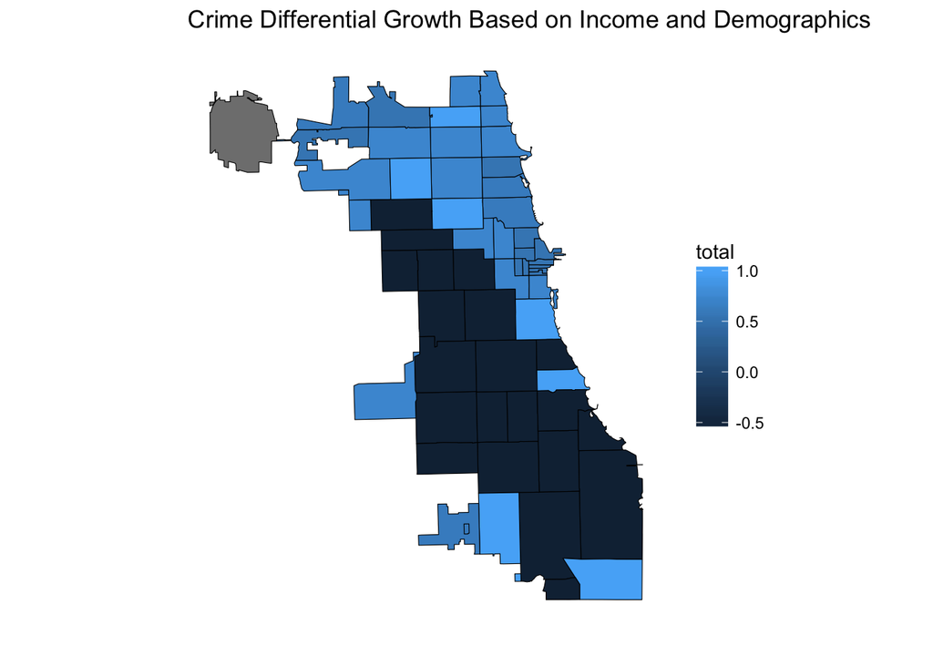

```r
model_3_map <- ggplot()
model_3_map <- model_3_map +  geom_polygon(data = crime_model_3_sigma, aes(x=long, y=lat, group=group, fill=sigma), color = "black", size=0.2)
model_3_map <- model_3_map + coord_map()
model_3_map <- model_3_map + labs(x="", y="", title=paste("Crime Differential Growth Based on Income and Demographics"), fill="total")
model_3_map <- model_3_map + cleanup
print(model_3_map)
```

```r
posterior_means
```

```
##     beta.1.     beta.2.     beta.3.     beta.4.     beta.5.    sigma.1.
## -8.54288605 -8.53084433 -7.89663773 -7.45596846 -7.67992852  0.61881602
##    sigma.2.    sigma.3.    sigma.4.    sigma.5.       tau_0       tau_1
##  0.54568448  0.74068777  1.00026574 -0.59811708  0.01863882  2.44962106
```

```r
#Five groups, 20% increase in percent white. Darkest blue is the areas with 20% or lower of population white.
#See Posterior means
```